# Quality of Red Wines Exploration by Clement viel

## Multivariate Plots Section

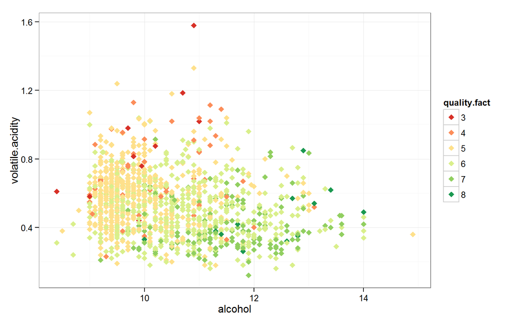

No doubt that the quality is a function of volatile.acidity and alcohol degree. The upper left corner concentrates the poorest wines, while the bottom right the better ones.

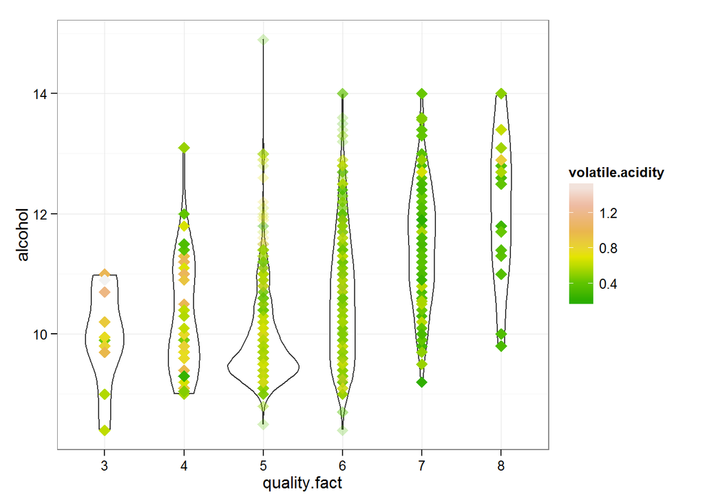

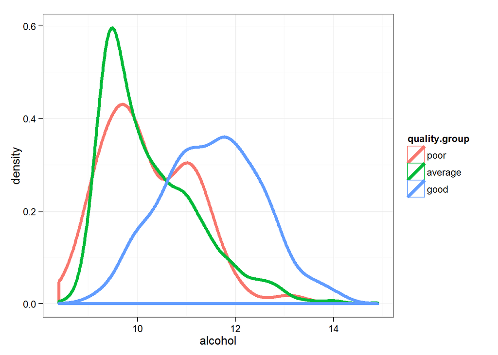

```
## rw$quality.group: poor
##    Min. 1st Qu.  Median    Mean 3rd Qu.    Max.
##    8.40    9.60   10.00   10.22   11.00   13.10
## --------------------------------------------------------
## rw$quality.group: average
##    Min. 1st Qu.  Median    Mean 3rd Qu.    Max.
##    8.40    9.50   10.00   10.25   10.90   14.90
## --------------------------------------------------------
## rw$quality.group: good
##    Min. 1st Qu.  Median    Mean 3rd Qu.    Max.
##    9.20   10.80   11.60   11.52   12.20   14.00
```

```
##
## Call:
## lm(formula = quality ~ alcohol + volatile.acidity + log10(sulphates) +
##     citric.acid + pH, data = subset(rw, quality.group != "average"))
##
## Residuals:
##      Min       1Q   Median       3Q      Max
## -3.12420 -0.46271  0.01201  0.54598  2.29650
##
## Coefficients:
##                  Estimate Std. Error t value Pr(>|t|)
## (Intercept)       8.52361    1.74047   4.897 1.66e-06 ***
## alcohol           0.53301    0.05565   9.579  < 2e-16 ***
## volatile.acidity -2.57989    0.33588  -7.681 2.81e-13 ***
## log10(sulphates)  2.93815    0.64397   4.563 7.63e-06 ***
## citric.acid      -0.84464    0.44070  -1.917 0.056330 .
## pH               -1.86424    0.53087  -3.512 0.000521 ***
## ---
## Signif. codes:  0 '***' 0.001 '**' 0.01 '*' 0.05 '.' 0.1 ' ' 1
##
## Residual standard error: 0.9239 on 274 degrees of freedom
## Multiple R-squared:  0.5653, Adjusted R-squared:  0.5573
## F-statistic: 71.26 on 5 and 274 DF,  p-value: < 2.2e-16
```

Once more, the distribution of the quality is clearly unbalanced. Classes *5* and *6* are very wide and overcounted compared to others.

However, when grouped by quality (*poor*, *average* and *good*), I see that the *good* class is normally distributed while the median of *poor* and *average* matches. So, the correlation could be better if addressed individually.

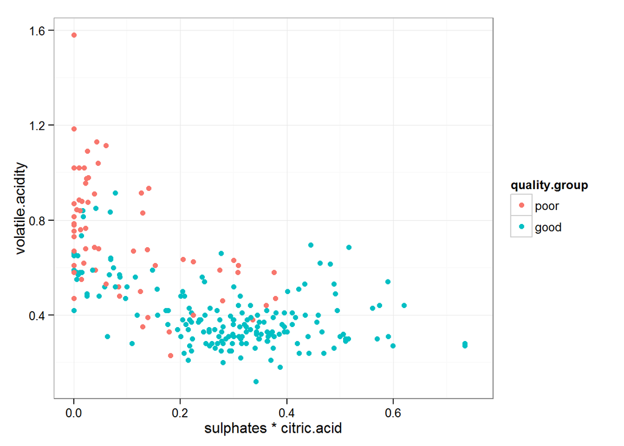

Volatile.acidity, sulphates and citric.acid draw two groups almost matching the quality scores.

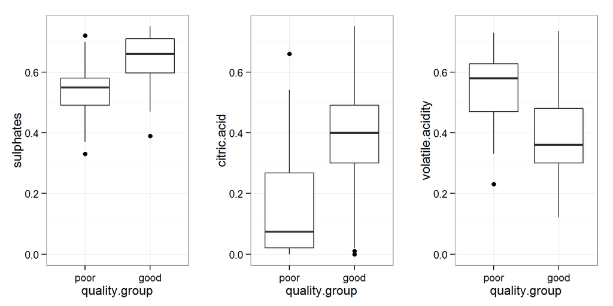

These features seem to be good predicators for the *poor* and *good* quality classes. I however keep in mind that quality *3* and *4* are smaller classes than *7* and *8*. This could be linked to a sampling bias effect.

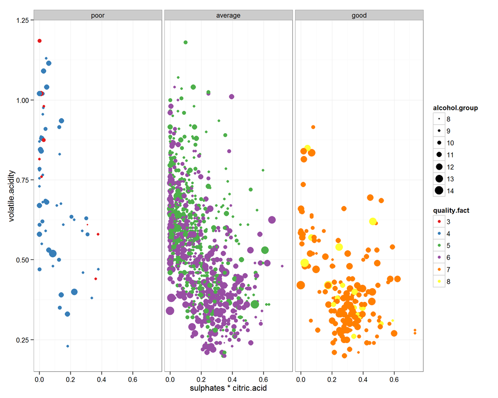

The four most relevant features (describing the quality output) put together.

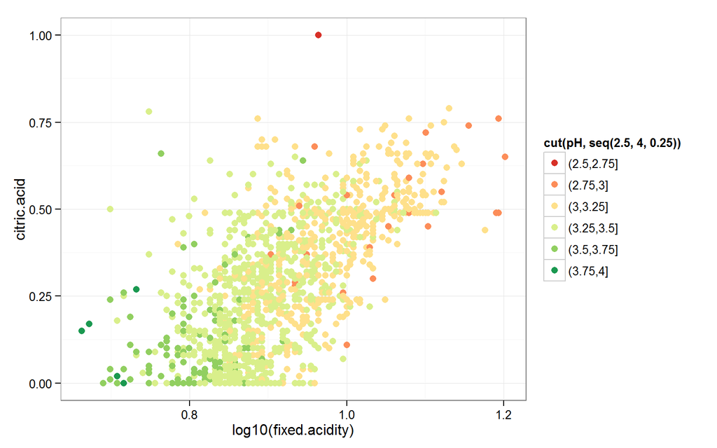

PH is, by no surprise, driven by the level of both citric.acid and log10(fixed.acidity) in wines.

## Multivariate Analysis

### Talk about some of the relationships you observed in this part of the investigation. Were there features that strengthened each other in terms of looking at your feature(s) of interest?

The low quality wines always show lower concentrations in sulphates and citric.acid.

Holding these two later variables constant, the quality of a wine is however better with the level of volatile.acidity decreasing.

While low and high quality are clear-cut classes, the average one is overlapping both and therefore makes it pretty hard to accurately predict the quality of a given wine.

### Were there any interesting or surprising interactions between features?

None of the features provided can really be used to identify the quality classes *5* and *6*. In fact, these averages quality wines take averages values for most of the variables, making it hard to predict with accuracy.

### OPTIONAL: Did you create any models with your dataset? Discuss the strengths and limitations of your model.

Following the multivariate exploratory analysis, I decided to go with the quality classes *poor* and *good* only using the same variable besides the pH. By doing so I was able to improve the model and reach a R² value of 0.56, which confirmed my findings about the quality distribution: *average* being overcounted and overlapping the two others classes (to the extent of the variables provided in the dataseet).

## Final Plots and Summary

### Plot One

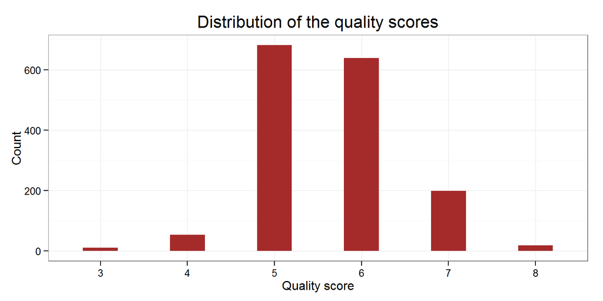

### Description One

The distribution of the quality scores appears to be clearly unbalanced. Average quality classes *5* and *6* are overcounted compared to others. This introduces a major bias in the analysis of the dataset.

### Plot Two

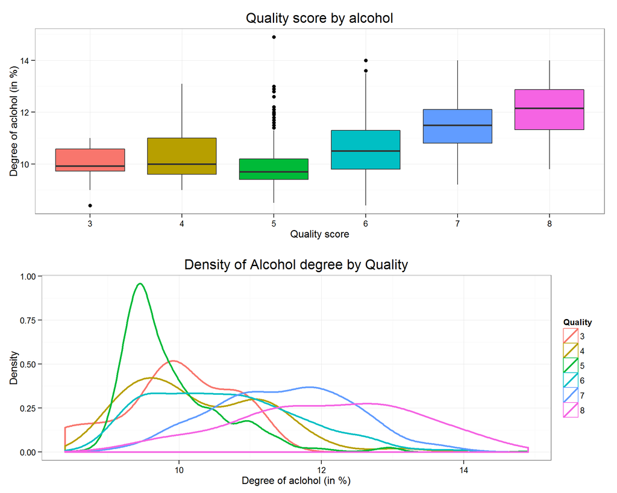

### Description two

The Alcohol degree is the most important contributor to the quality output. The more alcohol, the better a wine is. While it’s not really clear for quality classes between *3* and *5* (bi-modal densities and classes *5*’ median being the lowest), I do notice a flipping point between *5* and *6* from which the densities start spreading toward highest alcohol levels.

### Plot Three

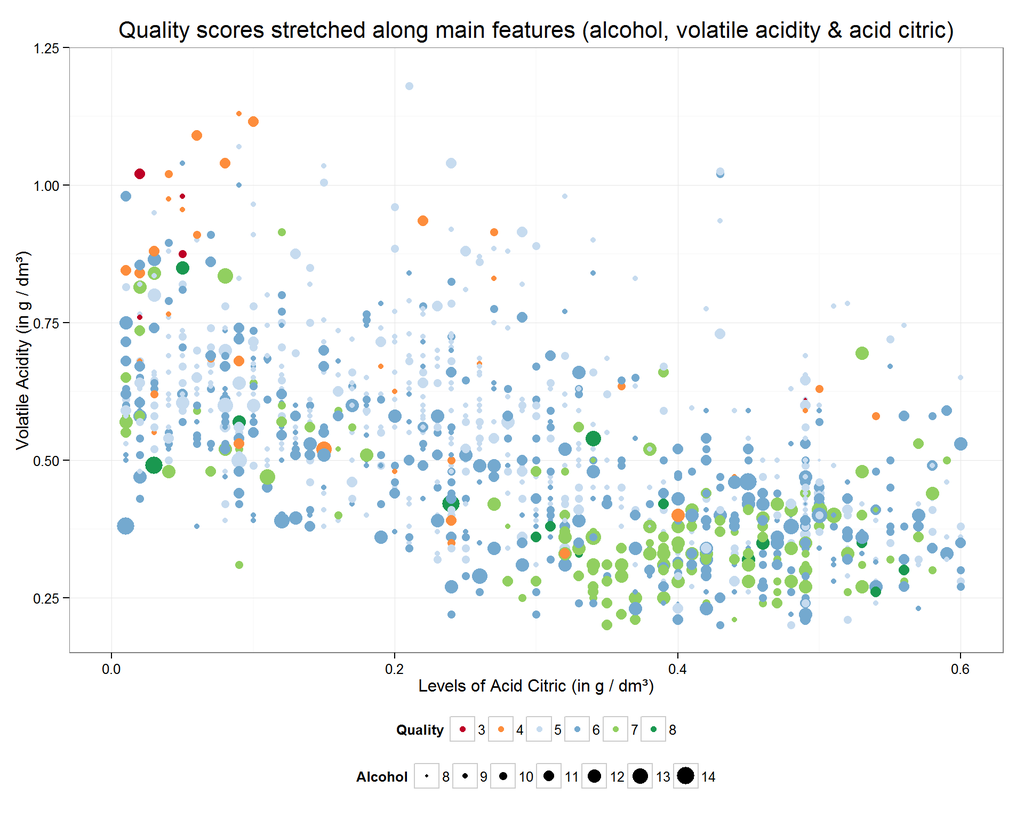

### Description Three

In this plot, the lower quality wines (classes *3* and *4*) cluster in the top left corner while the better ones (classes *7* and *8*) tend to be all regrouped in the bottom right corner. The variables Volatile.acidity and Citric.acid are enough to take this two group appart.  
In between, stand the average ones (classes *5* and *6*). The fact that they overlap with the two other groups suggests that none of the features used (or even existing in the dataset) significantly identify the average wines.  
This size of the points however confirm the previous finding about alcohol degree (the higher is better): green points are generally bigger than the red ones.

## Reflection

The red wines data set contains information on almost 1600 wines from around 2009. I started by understanding the individual variables in the data set, and then I explored interesting questions and leads as I continued to make observations on plots. Eventually, I explored the quality scores of the wines across many variables and created a linear model to predict it. I was however surprised that the model scored so poorly considering all the physicochemical variables the dataset contains. I did found a couple of variables correlating with the quality, but none of them neither them all together were enough to train a robust model (R²=35%). Besides some of the variables correlated pretty well between each other but didn’t improve whole the predicting model.

Some limitations of this model include the source of the data. It is clearly unbalanced, with average quality overcounted other classes. Hence, it makes it truly difficult to discover which variables best identify the lower and higher quality wines. In fact none of the variables could really helped isolating the average quality wines from others, there were always overlapping. Under such conditions the linear model couldn’t predict the quality with accuracy. It would be very interesting to work with a balanced dataset where the quality output is evenly distributed.

Finally, knowing the quality of the wine can’t be accurately derived from the wines features, I am therefore wondering how the quality was assigned. Did it follow a scientific methodology, in which case I obviously lack couple of features used, or was it the result of a pool of oenologists? According to the documentation, quality was defined as “the median of at least 3 evaluations made by wine experts”. So no real science behind but people’s own perception, that is, low chances to reach a very accurate model from this dataset.